# Methods Paper - Chapter 1

## 0.10 Section 6 - FINAL CLUSTERING

```r
cluster_resolution <- 0.35
output_dir <- dir_02
pbmc_harmony <- pbmc_harmony %>%
  RunUMAP(reduction = "harmony", dims = 1:30, verbose = FALSE) %>%
  FindNeighbors(reduction = "harmony", dims = 1:30,
                k.param = 20, verbose = FALSE) %>%
  FindClusters(resolution = cluster_resolution, algorithm = 4, verbose = FALSE)
Idents(pbmc_harmony) <- "seurat_clusters"
save_pdf(DimPlot(pbmc_harmony, group.by = "seurat_clusters", label = TRUE),
         "umap_seuratclusters.pdf")
message("\nOK SECTION 6 COMPLETE: Final clustering complete")
```

Representative output from Section 6:

[figure not shown]

Final UMAP colored by numbered Seurat clusters.

## 0.11 Section 7 - CELL-TYPE ANNOTATION

```r
output_dir <- dir_03
biblio_marks_file <- file.path(DATA_DIR, "biblio_marks_custom.txt")
marker_table      <- read.table(biblio_marks_file, header = TRUE, sep = "\t", quote = "")
markers <- find_markers(pbmc_harmony,
                        output_file = file.path(output_dir, "FindAllMarkers.tsv"))
pbmc_harmony <- annotate_by_markers(pbmc_harmony, markers,
                                    reference_file = biblio_marks_file)
plot_marker_dotplot(
  pbmc_harmony,
  marker_table,
  annot_col = "celltype",
  outfile   = file.path(output_dir, "dotplot_marker_table_annotation_biblio.pdf"),
  width = 18, height = 18
)
save_pdf(DimPlot(pbmc_harmony, group.by = "celltype",
                 label = TRUE, repel = TRUE, raster = FALSE),
         "umap_annotation_biblio.pdf")
message("\nOK SECTION 7 COMPLETE: Cell-type annotation complete")
```

Representative outputs from Section 7:

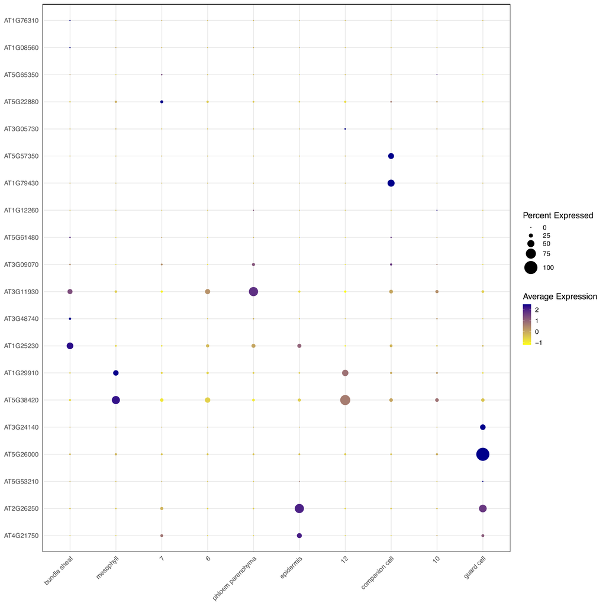

Marker dotplot after bibliography-based cell-type annotation.

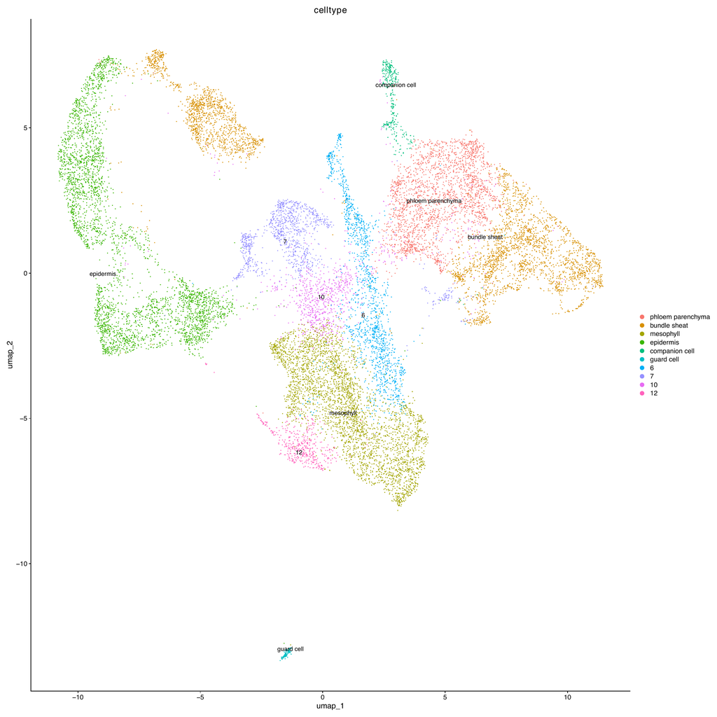

UMAP colored by bibliography-based cell-type annotation.

## 0.12 Section 8 - ANNOTATED CLUSTREE

```r
output_dir <- dir_03
Mode <- function(x) {
  x <- as.character(x)
  x <- x[!is.na(x) & nzchar(x)]
  if (length(x) == 0) return(NA_character_)
  names(sort(table(x), decreasing = TRUE))[1]
}
stopifnot(exists("clu"))
stopifnot("celltype" %in% colnames(pbmc_harmony@meta.data))
celltype_label <- as.character(pbmc_harmony$celltype)
names(celltype_label) <- Cells(pbmc_harmony)
clu$celltype_label <- celltype_label[Cells(clu)]
print(table(clu$celltype_label, useNA = "ifany"))
save_pdf(
  clustree(clu, prefix = "RNA_snn_res.",
           node_label = "celltype_label", node_label_aggr = "Mode"),
  "clustree_annotated.pdf", w = 14, h = 14
)
message("\nOK SECTION 8 COMPLETE: Annotated clustree saved")
```

Representative output from Section 8:

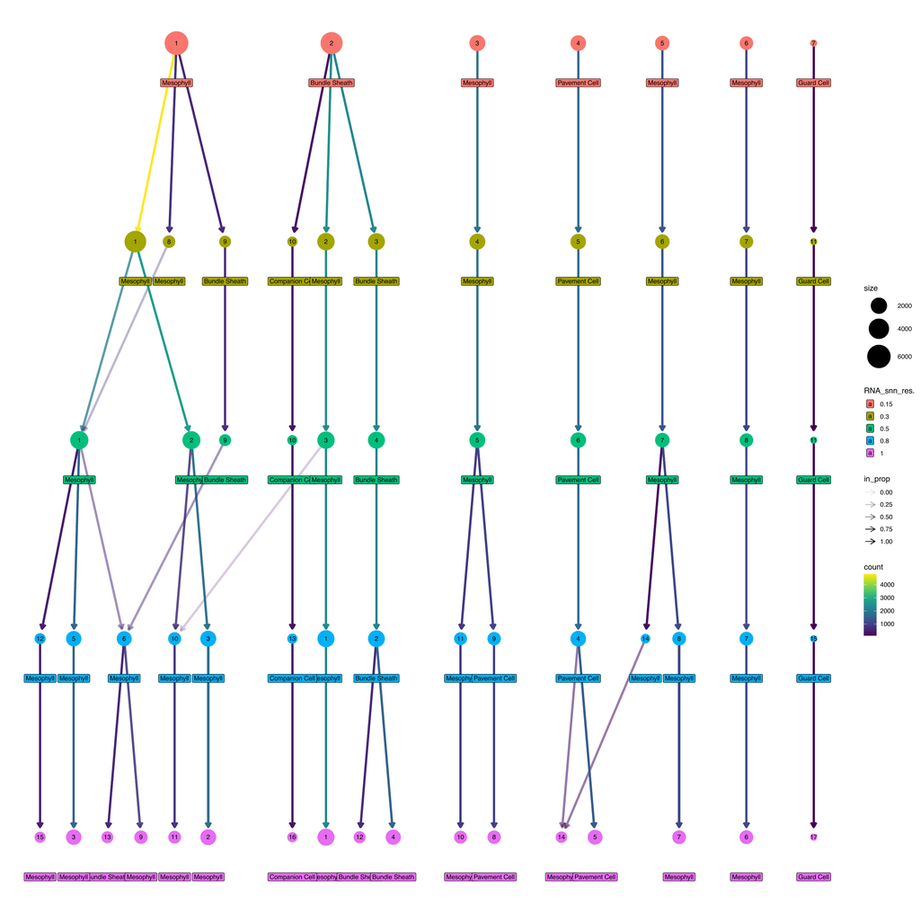

Cluster tree labeled by the dominant bibliography-based annotation in each node.

## 0.13 Section 9 - GENE EXPRESSION VISUALIZATION

```r
gene <- "AT5G26000"
output_dir <- dir_04
pbmc_harmony <- JoinLayers(pbmc_harmony)
Idents(pbmc_harmony) <- "celltype"
save_vln(
  VlnPlot(pbmc_harmony, features = gene),
  "vln_gene_all.pdf"
)
save_pdf(
  FeaturePlot(pbmc_harmony, features = gene),
  "feature_gene_all.pdf"
)
message("\nOK SECTION 9 COMPLETE: Gene expression visualization saved")
```

Representative outputs from Section 9:

[figure not shown]

Violin plot for the selected gene across all annotated cell types.

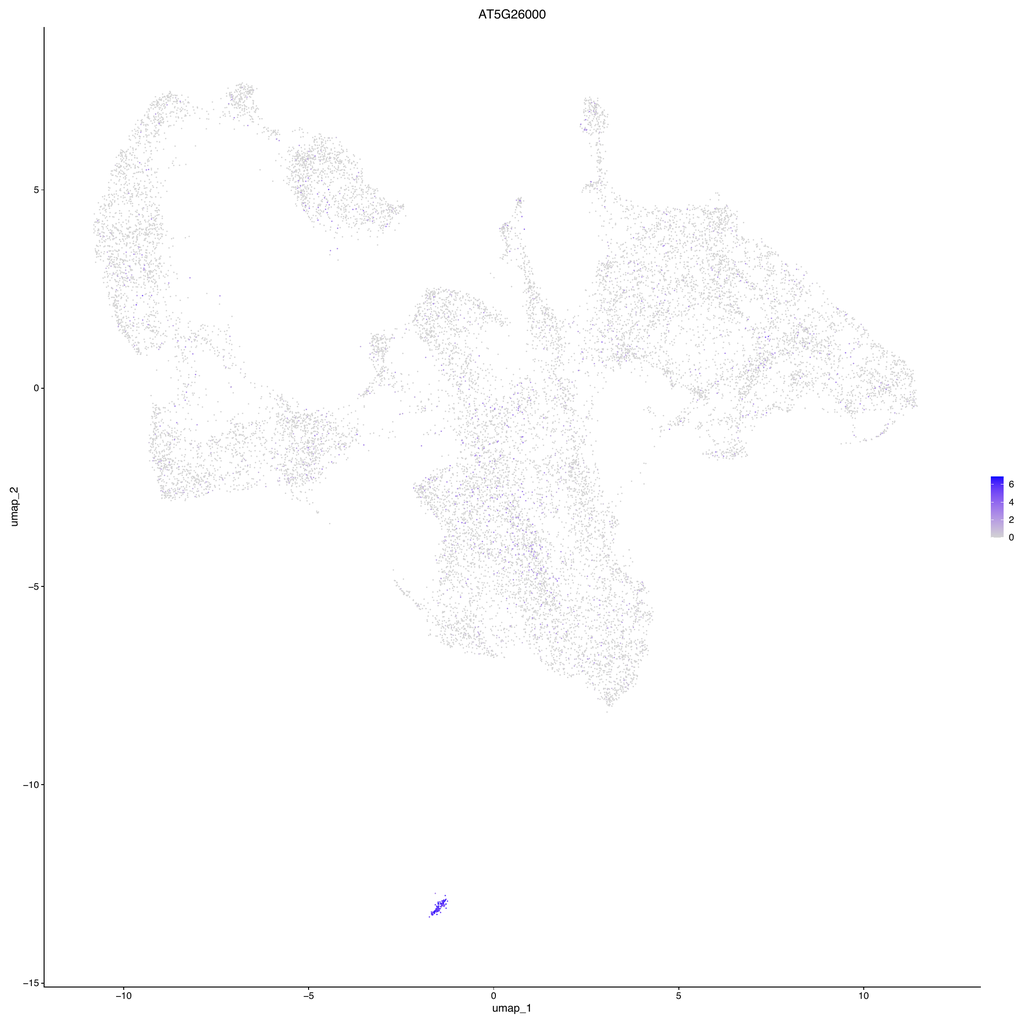

UMAP expression overlay for the selected gene.

## 0.14 Section 10 - CELL-TYPE GROUPING [OPTIONAL]

```r
grouping <- c()
output_dir <- dir_05
if (length(grouping) > 0) {
  pbmc_harmony$celltype_grouped <- recode(pbmc_harmony$celltype, !!!grouping)
} else {
  pbmc_harmony$celltype_grouped <- pbmc_harmony$celltype
}
save_pdf(
  DimPlot(pbmc_harmony, group.by = "celltype_grouped",
          label = TRUE, repel = TRUE, raster = FALSE),
  "umap_grouped.pdf"
)
message("\nOK SECTION 10 COMPLETE: Cell-type grouping complete")
```

Representative output from Section 10:

[figure not shown]

UMAP colored by grouped cell-type labels.

## 0.15 Section 11 - SUBCLUSTER MARKER INSPECTION [OPTIONAL]

This section is intentionally interactive. It is used to test marker expression against subclusters before deciding whether manual curation is needed. The section does not modify `pbmc_harmony` by default. Individual subcluster UMAPs are saved in a wide format so that UMAP dimensions keep the same visual proportions and do not appear compressed in the report.

```r
output_dir   <- dir_05
curation_col <- "celltype"
Idents(pbmc_harmony) <- curation_col
print(table(pbmc_harmony[[curation_col]], useNA = "ifany"))
types_to_inspect <- c("2","4","5","8")
subcluster_resolution <- 0.3
subcluster_dims       <- 1:20
subcluster_list    <- list()
inspection_entries <- list()
for (ct in types_to_inspect) {
  safe_name <- make.names(ct)
  file_tag  <- gsub("[^A-Za-z0-9]+", "_", ct)
  message("\nInspecting: ", ct)
  sub_obj <- subcluster_cell_type(
    pbmc_harmony,
    tipo       = ct,
    annot_col  = curation_col,
    resolution = subcluster_resolution,
    dims       = subcluster_dims
  )
  subcluster_list[[safe_name]] <- sub_obj
  print(table(sub_obj$cluster_subtipo, useNA = "ifany"))
  p_dim <- plot_subcluster_umap(sub_obj, ct, output_dir)
  plot_marker_dotplot(
    sub_obj,
    marker_table,
    annot_col = "cluster_subtipo",
    outfile   = file.path(output_dir, paste0("dotplot_markers_subclusters_", file_tag, ".pdf")),
    width = 18,
    height = 18
  )
  inspection_entries[[safe_name]] <- list(
    umap_plot = p_dim,
    obj       = sub_obj
  )
}
save_subcluster_composite(
  subcluster_list = inspection_entries,
  marker_table    = marker_table,
  output_dir      = output_dir,
  filename        = "subclustering_marker_inspection2.pdf"
)
message("\nOK SECTION 11 COMPLETE: Subcluster marker inspection saved")
```

Representative output from Section 11:

[figure not shown]

Example subcluster UMAP used for manual marker inspection.

## 0.16 Current stopping point

This methods draft stops at optional subcluster marker inspection. Export to h5ad, pseudobulk, DESeq2, enrichment, network analysis, and pseudotime are not included in this version.

## 0.17 Supplementary information

### 0.17.1 Docker image program and package versions

The following version tables were generated from the active Docker container used to render this methods draft. The complete machine-readable files are kept next to this R Markdown file:

```
reports/docker_cli_versions.tsv
reports/docker_r_package_versions.tsv
reports/docker_python_package_versions.tsv
```

Command-line tools detected in the Docker image.

| program | version |
| --- | --- |
| R | R version 4.5.3 (2026-03-11) – Reassured Reassurer |
| Rscript | Rscript (R) version 4.5.3 (2026-03-11) |
| python3 | Python 3.12.3 |
| pip | pip 26.1.2 from /opt/venv/lib/python3.12/site-packages/pip (python 3.12) |
| pandoc | pandoc 3.1.3 |
| cellranger | not installed in Docker image |
| samtools | not installed in Docker image |
| bedtools | not installed in Docker image |
| bowtie2 | not installed in Docker image |
| bwa | not installed in Docker image |
| STAR | not installed in Docker image |
| salmon | not installed in Docker image |
| kallisto | not installed in Docker image |
| fastqc | not installed in Docker image |
| multiqc | not installed in Docker image |

R package inventory in the Docker image, excluding base/recommended R packages.

|  | Package | Version | Priority | LibPath |
| --- | --- | --- | --- | --- |
| 1 | abind | 1.4-8 | NA | /usr/local/lib/R/site-library |
| 2 | anndataR | 1.0.2 | NA | /usr/local/lib/R/site-library |
| 3 | AnnotationDbi | 1.72.0 | NA | /usr/local/lib/R/site-library |
| 4 | ape | 5.8-1 | NA | /usr/local/lib/R/site-library |
| 5 | aplot | 0.2.9 | NA | /usr/local/lib/R/site-library |
| 6 | askpass | 1.2.1 | NA | /usr/local/lib/R/site-library |
| 7 | assertthat | 0.2.1 | NA | /usr/local/lib/R/site-library |
| 8 | assorthead | 1.4.0 | NA | /usr/local/lib/R/site-library |
| 9 | backports | 1.5.1 | NA | /usr/local/lib/R/site-library |
| 11 | base64enc | 0.1-6 | NA | /usr/local/lib/R/site-library |
| 12 | basilisk | 1.22.0 | NA | /usr/local/lib/R/site-library |
| 13 | batchelor | 1.26.0 | NA | /usr/local/lib/R/site-library |
| 14 | beachmat | 2.26.0 | NA | /usr/local/lib/R/site-library |
| 15 | beeswarm | 0.4.0 | NA | /usr/local/lib/R/site-library |
| 16 | BH | 1.90.0-1 | NA | /usr/local/lib/R/site-library |
| 17 | biglm | 0.9-3 | NA | /usr/local/lib/R/site-library |
| 18 | Biobase | 2.70.0 | NA | /usr/local/lib/R/site-library |
| 19 | BiocGenerics | 0.56.0 | NA | /usr/local/lib/R/site-library |
| 20 | BiocManager | 1.30.27 | NA | /usr/local/lib/R/site-library |
| 21 | BiocNeighbors | 2.4.0 | NA | /usr/local/lib/R/site-library |
| 22 | BiocParallel | 1.44.0 | NA | /usr/local/lib/R/site-library |
| 23 | BiocSingular | 1.26.1 | NA | /usr/local/lib/R/site-library |
| 24 | BiocVersion | 3.22.0 | NA | /usr/local/lib/R/site-library |
| 25 | Biostrings | 2.78.0 | NA | /usr/local/lib/R/site-library |
| 26 | bit | 4.6.0 | NA | /usr/local/lib/R/site-library |
| 27 | bit64 | 4.8.2 | NA | /usr/local/lib/R/site-library |
| 28 | bitops | 1.0-9 | NA | /usr/local/lib/R/site-library |
| 29 | blob | 1.3.0 | NA | /usr/local/lib/R/site-library |
| 32 | BPCells | 0.3.1 | NA | /usr/local/lib/R/site-library |
| 33 | brew | 1.0-10 | NA | /usr/local/lib/R/site-library |

[output cut: 376 more lines]

Complete Python package inventory in the Docker image.

| Package | Version |
| --- | --- |
| adjustText | 1.3.0 |
| anndata | 0.12.16 |
| annotated-types | 0.7.0 |
| anyio | 4.13.0 |
| argon2-cffi | 25.1.0 |
| argon2-cffi-bindings | 25.1.0 |
| array-api-compat | 1.14.0 |
| arrow | 1.4.0 |
| asttokens | 3.0.1 |
| async-lru | 2.3.0 |
| attrs | 26.1.0 |
| babel | 2.18.0 |
| beautifulsoup4 | 4.14.3 |
| bleach | 6.3.0 |
| blosc2 | 4.4.1 |
| cellbender | 0.3.2 |
| certifi | 2026.5.20 |
| cffi | 2.0.0 |
| charset-normalizer | 3.4.7 |
| click | 8.4.1 |
| comm | 0.2.3 |
| contourpy | 1.3.3 |
| cuda-bindings | 13.3.1 |
| cuda-pathfinder | 1.5.5 |
| cuda-toolkit | 13.0.2 |
| cycler | 0.12.1 |
| debugpy | 1.8.21 |
| decorator | 5.3.1 |
| defusedxml | 0.7.1 |
| donfig | 0.8.1.post1 |

[output cut: 177 more lines]